# Spatial Analysis of Electricity Access Inequality in Indonesia

Spatial Statistics and Machine Learning on District-Level INDO-DAPOER Data (2019)

Nanda Zahri Wibowo

15 July 2026

# 1 Introduction

## 1.1 Background

Indonesia is the world’s largest archipelagic state: more than 17,000 islands spread across three time zones, with enormous variation in geography, income, and infrastructure. Electricity is a foundational input for education, health services, and economic activity, and Indonesia has made remarkable progress in extending it: the national electrification programme pushed household access from roughly two-thirds of households in the 1990s to near-universal coverage today (World Bank, 2021; IEA, 2020).

That national success, however, hides a sharp spatial story. By 2019 the *median* Indonesian district (kabupaten/kota) had essentially closed its electricity gap, yet a small set of districts – concentrated in Papua, Nusa Tenggara Timur, and Maluku – still had a substantial share of households without electricity, in the most extreme case almost the entire district. The policy problem has therefore shifted from “raising the average” to “reaching the last places”, and those last places are not scattered at random: they cluster in specific corners of the archipelago.

This study examines that residual inequality using district-level data for 2019 from INDO-DAPOER, the Indonesia Database for Policy and Economic Research compiled jointly by the World Bank and BPS-Statistics Indonesia. The outcome of interest is the **electricity access deficit**: the percentage of households in a district *without* access to electricity.

## 1.2 Research Questions

1. How is the electricity access deficit distributed across Indonesian districts, and how large are the remaining disparities?
2. Which socio-economic characteristics are associated with the deficit?
3. Does the deficit exhibit spatial clustering, and where are the hotspots?
4. How well can machine learning models predict the district-level deficit from socio-economic variables, and which variables matter most?
5. What do simple policy scenarios suggest about the potential of complementary development interventions?

## 1.3 Significance

- **Academic**: adds district-level (rather than province-level) evidence on energy inequality in a developing archipelagic country, combining spatial econometrics with machine learning.
- **Practical**: identifies the specific district clusters where the remaining electrification effort should be concentrated.
- **Methodological**: demonstrates a fully reproducible pipeline from a public API to the final report; every figure in this document is generated from the raw data.

# 2 Literature Review

## 2.1 Energy Inequality

Energy inequality denotes disparities in access to, and quality of, modern energy services across social groups or regions. In developing countries it typically appears as an urban-rural or core-periphery divide, and it is increasingly measured not by national averages but by the distribution of access across sub-national units (IEA, 2020). When access approaches 100% nationally, the analytically interesting quantity becomes the *deficit* in the lagging tail of the distribution – the framing adopted here.

## 2.2 Regional Development Theory

Core-periphery models of regional development (Myrdal, 1957; Hirschman, 1958) predict that capital, labour, and infrastructure agglomerate in core regions, while peripheral regions face cumulative disadvantage: low density and difficult terrain raise the unit cost of infrastructure, low incomes weaken demand, and weak infrastructure in turn depresses income. Indonesia is a textbook case: Java-Bali forms the demographic and economic core, while the eastern islands – especially the Papuan highlands – are the classic periphery. This theory motivates two empirical expectations: (i) the access deficit should correlate with broader development indicators, and (ii) it should be spatially clustered rather than randomly scattered.

## 2.3 Determinants of Electricity Access

Prior empirical work points to a consistent set of correlates of electricity access in developing countries:

- **Income and expenditure**: richer households and richer regions can afford connections and attract grid investment.
- **Human development**: composite indices such as the HDI capture education and health conditions that co-evolve with infrastructure.
- **Poverty**: poverty headcounts flag the demand-side constraint directly.
- **Population density**: grid extension has strong economies of density; sparse settlement raises per-connection cost.
- **Complementary infrastructure**: access to safe water proxies the general reach of public service delivery into a district.

## 2.4 Spatial Methods and Machine Learning

Global Moran’s I (Moran, 1950) tests whether a variable is spatially autocorrelated overall; LISA statistics (Anselin, 1995) locate the specific clusters; and the Getis-Ord Gi* statistic (Getis & Ord, 1992; Ord & Getis, 1995) identifies statistically significant hot- and coldspots. Spatial lag regression (Anselin, 1988) incorporates neighbourhood spillovers directly in a regression framework. On the predictive side, ensemble tree methods – Random Forest (Breiman, 2001) and gradient boosting (Chen & Guestrin, 2016) – and regularised regression (Friedman, Hastie & Tibshirani, 2010) are standard tools for tabular prediction and permit variable-importance and partial-dependence interpretation. This study combines the two strands.

# 3 Methodology

## 3.1 Data Sources

All data are original, public, and fully traceable; the raw API responses are archived in the project’s `data/raw_dapoer/` folder **and** `build_dataset.R` re-downloads any missing file automatically from the original public APIs, so the dataset is both included with the submission and automatically downloadable in code. This dataset is not among the well-known teaching datasets (iris, titanic, MNIST, MovieLens, etc.) and this project is unrelated to the MovieLens recommender project.

1. **INDO-DAPOER** (Indonesia Database for Policy and Economic Research), World Bank & BPS-Statistics Indonesia. District-level indicators for **2019** – the most recent year with complete district coverage – retrieved from the World Bank API v2 (source id 45) on 14 July 2026.
2. **geoBoundaries** gbOpen release, Indonesia ADM2 boundaries (519 units, 2020 vintage; Runfola et al., 2020), used for district centroids and land areas.

The 514 DAPOER districts were matched to boundary polygons by normalised name and type (regency/city); nine districts required documented manual matches for official renames (e.g. Kabupaten Pontianak became Mempawah under Government Regulation 58/2014). Six districts are excluded for missing 2019 values: Buton Selatan, Buton Tengah, and Muna Barat (created in 2014, no population figures in DAPOER) and Deiyai, Mamberamo Tengah, and Puncak in Papua (no safe-water figures). This leaves **508 districts** with complete data on every variable used in the analysis.

```r
# If the analysis outputs are missing, run the full pipeline once
# (the analysis script also rebuilds the dataset itself if needed).
if (!file.exists("output/final_analysis_results.csv")) {
  message("Analysis outputs not found -- running the analysis script now ...")
  source("analysis_electricity_access_inequality_indonesia_FINAL.R")
}
stopifnot(file.exists("output/final_analysis_results.csv"))
data <- read_csv("output/final_analysis_results.csv", show_col_types = FALSE)
cat("Districts loaded:", nrow(data), "\n")
```

```
## Districts loaded: 508
```

## 3.2 Variables

| Variable | INDO-DAPOER series | Description |
| --- | --- | --- |
| `access_deficit` | HOU.ELC.ACSN.ZS | 100 minus % of households with electricity |
| `hdi` | IDX.HDI.REV | Human Development Index, revised method (0-100) |
| `poverty_rate` | SI.POV.NAPR.ZS | Poverty headcount (% of population) |
| `expenditure_pc_thousand` | HOU.XPD.PC.CR | Household expenditure per capita (thousand IDR/month) |
| `grdp_per_capita` | NA.GDP.INC.OG.SNA08.KR / SP.POP.TOTL | GRDP per person (constant-price, IDR million) |
| `population_density` | SP.POP.TOTL / polygon area | People per km$^2$ |
| `water_access` | HOU.H2O.ACSN.ZS | % of households with safe water |
| `literacy_rate` | SE.LITR.15UP.ZS | Literacy, population 15+ (%) |
| `is_city` | location type | 1 = kota (city), 0 = kabupaten (regency) |

Density and GRDP per capita enter models in $\log_{10}$ form because both are heavily right-skewed.

## 3.3 Analytical Techniques

**Exploratory analysis.** Distributions, Spearman correlations (robust to the extreme skew of the deficit), and provincial rankings.

**Spatial statistics.** A k-nearest-neighbour spatial weights matrix ($k = 5$, row-standardised) built on district centroids – appropriate for an archipelago where contiguity is undefined across water. We compute global Moran’s I, LISA cluster maps, Getis-Ord Gi* hotspots, and a spatial lag model (`spatialreg::lagsarlm`).

**Machine learning.** Four models – OLS, Random Forest, XGBoost, Elastic Net – trained on an 80% split with 10-fold cross-validation and compared on the 20% hold-out by RMSE, MAE, and $R^2$. The best model is interpreted through variable importance and partial dependence.

**Policy simulation.** The best model predicts the national mean deficit under counterfactual scenarios: HDI +5 points, poverty $-25\%$, safe-water access +10 percentage points, and all three combined. These are associative (not causal) what-if illustrations.

**Software.** All analyses were conducted in R (R Core Team, 2024). Spatial statistics use the `spdep` and `spatialreg` packages (Bivand et al., 2013), machine learning uses `randomForest` (Breiman, 2001; Liaw & Wiener, 2002), `xgboost` (Chen & Guestrin, 2016), and `glmnet` (Friedman et al., 2010), and graphics use `ggplot2` (Wickham, 2016).

# 4 Results and Discussion

## 4.1 Descriptive Statistics

```r
desc <- data %>%
  select(access_deficit, hdi, poverty_rate, population_density,
         grdp_per_capita, water_access) %>%
  pivot_longer(everything(), names_to = "Variable") %>%
  group_by(Variable) %>%
  summarise(Min = min(value), Q1 = quantile(value, .25), Median = median(value),
            Mean = mean(value), Q3 = quantile(value, .75), Max = max(value),
            .groups = "drop")

show_table(desc, "Descriptive statistics, 508 districts (2019)")
```

Descriptive statistics, 508 districts (2019)

| Variable | Min | Q1 | Median | Mean | Q3 | Max |
| --- | --- | --- | --- | --- | --- | --- |
| access_deficit | 0.00 | 0.00 | 0.45 | 3.43 | 2.33 | 96.00 |
| grdp_per_capita | 0.01 | 18.70 | 26.77 | 38.17 | 39.92 | 487.90 |
| hdi | 30.75 | 66.44 | 69.23 | 69.69 | 72.84 | 86.65 |
| population_density | 0.83 | 54.25 | 151.51 | 1,118.61 | 814.43 | 20,539.55 |
| poverty_rate | 1.68 | 6.64 | 9.63 | 11.79 | 14.74 | 42.92 |
| water_access | 0.29 | 58.65 | 71.93 | 68.73 | 83.13 | 100.00 |

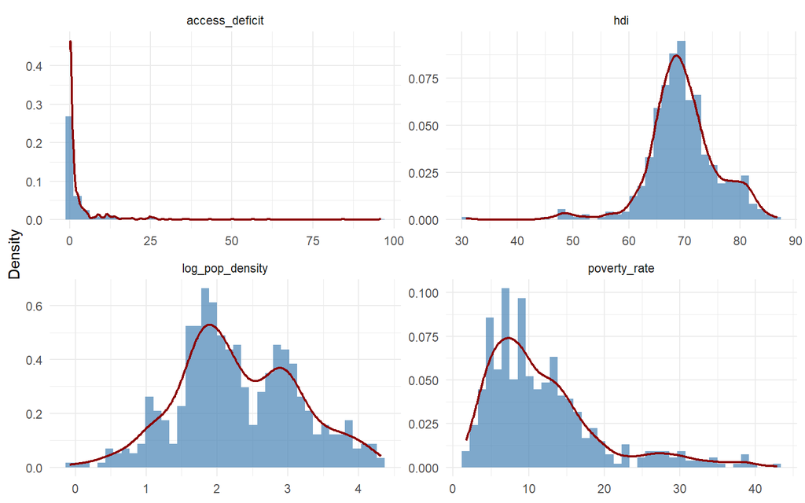

Distributions of the access deficit and key predictors

```r
data %>%
  select(access_deficit, hdi, poverty_rate, log_pop_density) %>%
  pivot_longer(everything(), names_to = "variable", values_to = "value") %>%
  ggplot(aes(x = value)) +
  geom_histogram(aes(y = after_stat(density)), bins = 40,
                 fill = "steelblue", alpha = 0.7) +
  geom_density(color = "darkred", linewidth = 0.8) +
  facet_wrap(~variable, scales = "free") +
  labs(x = NULL, y = "Density") +
  theme_minimal()
```

The most striking feature is the extreme skew of the outcome. The median district has a deficit of only 0.45%, and three-quarters of districts are below 2.33% – electrification is essentially complete for most of Indonesia. Yet the maximum reaches 96% (Kabupaten Dogiyai in the Papuan highlands, where only about 4% of households had electricity in 2019). The distribution of HDI is roughly symmetric around 69.7, while poverty and density are right-skewed, as expected.

## 4.2 Correlation Analysis

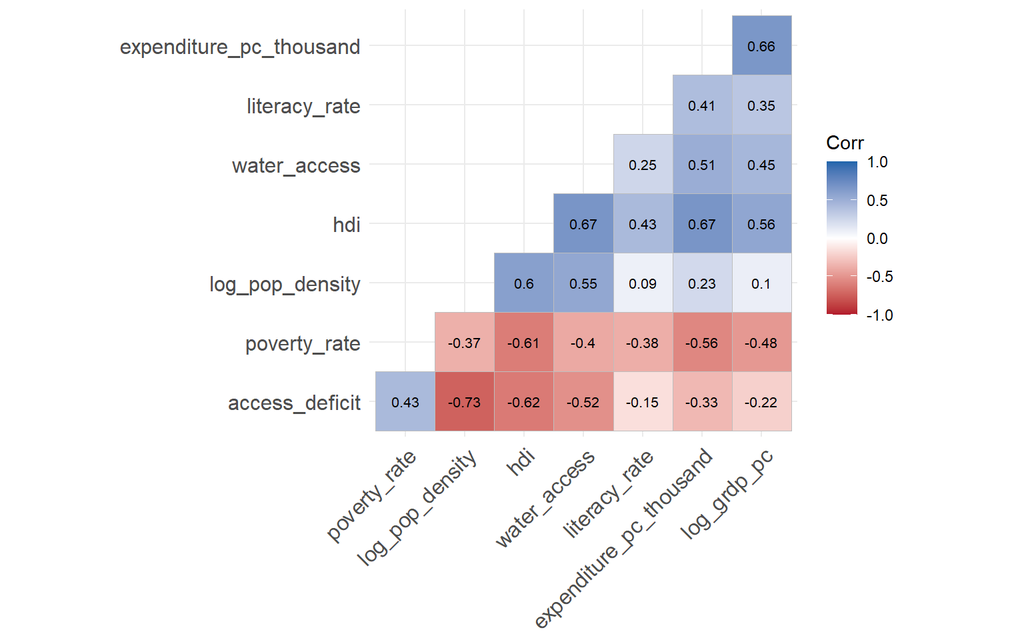

Spearman correlation matrix of key variables

```r
corr <- data %>%
  select(access_deficit, hdi, poverty_rate, expenditure_pc_thousand,
         log_pop_density, log_grdp_pc, water_access, literacy_rate) %>%
  cor(method = "spearman")

ggcorrplot(corr, hc.order = TRUE, type = "lower", lab = TRUE, lab_size = 2.8,
           colors = c("#B2182B", "white", "#2166AC"),
           ggtheme = theme_minimal)
```

## 4.3 Provincial Disparities

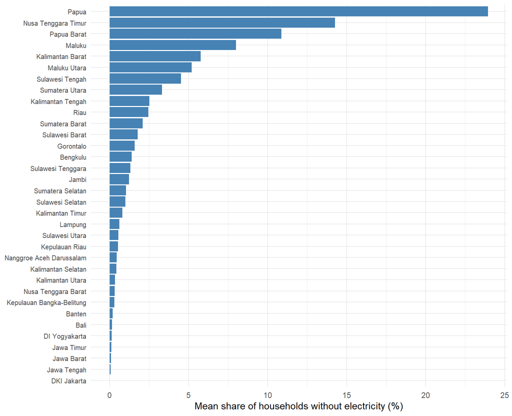

Mean electricity access deficit by province, 2019

```r
prov <- read_csv("output/province_summary.csv", show_col_types = FALSE)

prov %>%
  ggplot(aes(x = reorder(province, mean_deficit), y = mean_deficit)) +
  geom_col(fill = "steelblue") +
  coord_flip() +
  labs(x = NULL, y = "Mean share of households without electricity (%)") +
  theme_minimal() +
  theme(axis.text.y = element_text(size = 7.5))
```

```r
prov_tbl <- bind_rows(
  prov %>% slice_max(mean_deficit, n = 5) %>% mutate(Group = "Highest deficit"),
  prov %>% slice_min(mean_deficit, n = 5) %>% mutate(Group = "Lowest deficit")
) %>%
  select(Group, Province = province, `Mean deficit (%)` = mean_deficit,
         `Worst district (%)` = worst_deficit, Districts = districts)

show_table(prov_tbl, "Provinces with the highest and lowest mean access deficit (2019)")
```

Provinces with the highest and lowest mean access deficit (2019)

| Group | Province | Mean deficit (%) | Worst district (%) | Districts |
| --- | --- | --- | --- | --- |
| Highest deficit | Papua | 23.96 | 96.00 | 26 |
| Highest deficit | Nusa Tenggara Timur | 14.26 | 36.47 | 22 |
| Highest deficit | Papua Barat | 10.86 | 43.21 | 13 |
| Highest deficit | Maluku | 8.01 | 25.01 | 11 |
| Highest deficit | Kalimantan Barat | 5.75 | 16.64 | 14 |
| Lowest deficit | DKI Jakarta | 0.00 | 0.00 | 6 |
| Lowest deficit | Jawa Tengah | 0.06 | 0.26 | 35 |
| Lowest deficit | Jawa Barat | 0.09 | 1.11 | 28 |
| Lowest deficit | Jawa Timur | 0.10 | 1.26 | 38 |
| Lowest deficit | DI Yogyakarta | 0.13 | 0.42 | 5 |

The provincial ranking is unambiguous. Papua’s districts average a 24% deficit – an order of magnitude above the national norm – followed by Nusa Tenggara Timur (14.3%) and Papua Barat (10.9%). At the other end, the provinces of Java, Bali, and several Sumatran provinces are effectively at zero. Within provinces, heterogeneity can be large: Sumatera Barat averages only 2.1% yet contains Kepulauan Mentawai at roughly 26%, a reminder that isolated island districts lag even inside otherwise well-served provinces.

## 4.4 Spatial Analysis

### 4.4.1 Global Spatial Autocorrelation

```r
coords <- as.matrix(data[, c("longitude", "latitude")])
nb     <- knn2nb(knearneigh(coords, k = 5))
listw  <- nb2listw(nb, style = "W")

moran <- moran.test(data$access_deficit, listw)
moran_tbl <- tibble(
  Statistic = c("Moran's I", "Expectation", "Variance", "p-value"),
  Value = c(round(moran$estimate[1], 4), round(moran$estimate[2], 4),
            round(moran$estimate[3], 6),
            signif(moran$p.value, 3))
)
show_table(moran_tbl, "Global Moran's I for the access deficit (k = 5 neighbours)",
           digits = 4)
```

Global Moran’s I for the access deficit (k = 5 neighbours)

| Statistic | Value |
| --- | --- |
| Moran’s I | 0.4768 |
| Expectation | -0.0020 |
| Variance | 0.0006 |
| p-value | 0.0000 |

Moran’s I is 0.477 with a p-value below $10^{-15}$: the access deficit is strongly and significantly spatially autocorrelated. Districts with large deficits neighbour other high-deficit districts.

### 4.4.2 Spatial Distribution and Hotspots

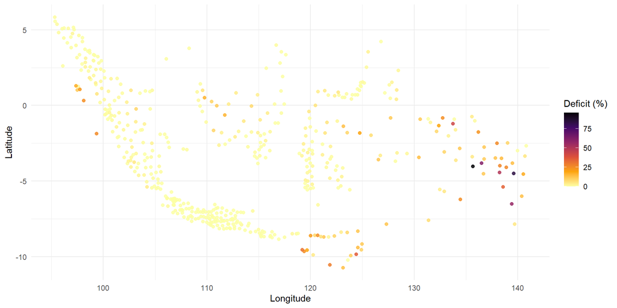

Access deficit at district centroids, 2019

```r
ggplot(data, aes(longitude, latitude, color = access_deficit)) +
  geom_point(size = 1.6, alpha = 0.85) +
  scale_color_viridis_c(option = "inferno", direction = -1) +
  labs(x = "Longitude", y = "Latitude", color = "Deficit (%)") +
  theme_minimal()
```

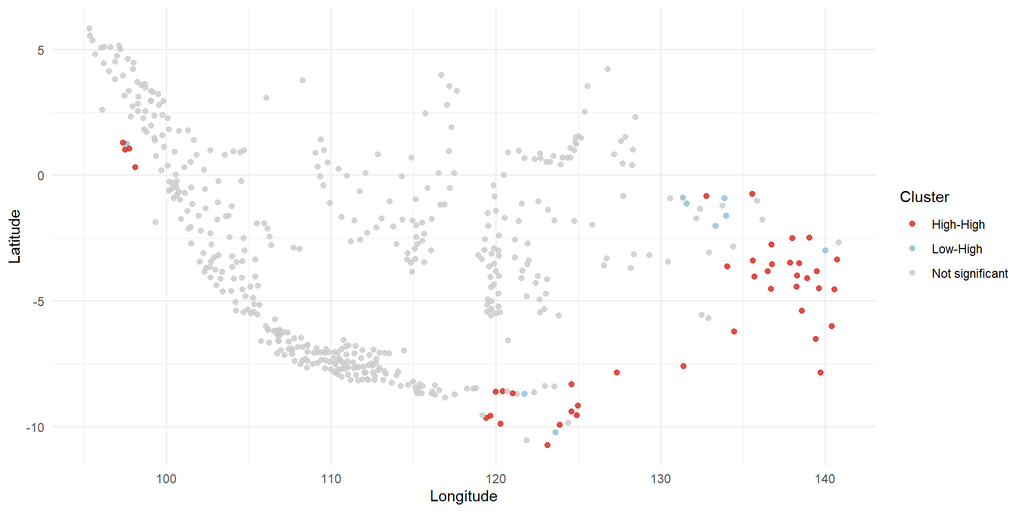

LISA clusters of the access deficit

```r
ggplot(data, aes(longitude, latitude, color = lisa_cluster)) +
  geom_point(size = 1.6, alpha = 0.85) +
  scale_color_manual(values = c("High-High" = "#D73027", "Low-Low" = "#4575B4",
                                "High-Low" = "#FC8D59", "Low-High" = "#91BFDB",
                                "Not significant" = "grey80")) +
  labs(x = "Longitude", y = "Latitude", color = "Cluster") +
  theme_minimal()
```

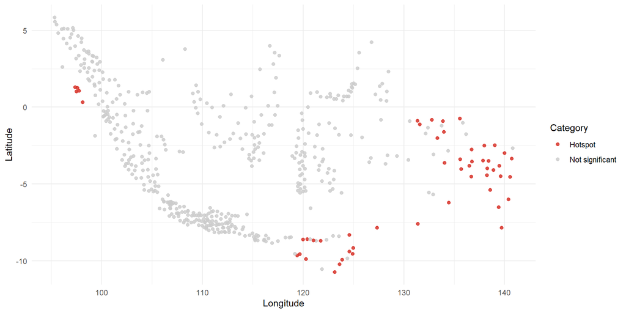

Getis-Ord Gi* hotspots of the access deficit

```r
ggplot(data, aes(longitude, latitude, color = hotspot)) +
  geom_point(size = 1.6, alpha = 0.85) +
  scale_color_manual(values = c("Hotspot" = "#D73027", "Coldspot" = "#4575B4",
                                "Not significant" = "grey80")) +
  labs(x = "Longitude", y = "Latitude", color = "Category") +
  theme_minimal()
```

```r
cluster_tbl <- data %>% count(lisa_cluster, name = "Districts") %>%
  rename(`LISA cluster` = lisa_cluster)
show_table(cluster_tbl, "LISA cluster membership", digits = 0)
```

LISA cluster membership

| LISA cluster | Districts |
| --- | --- |
| High-High | 43 |
| Low-High | 9 |
| Not significant | 456 |

The LISA analysis identifies 43 High-High districts – high deficits surrounded by high deficits – overwhelmingly in Papua (22) and Nusa Tenggara Timur (12), with the remainder in Maluku, Papua Barat, and the Nias islands of Sumatera Utara. The Gi* statistic flags 52 hotspot districts in the same regions. There are no Low-Low clusters or coldspots: because most of the country sits at (near-)zero deficit, “low” is the norm rather than a distinctive cluster. Inequality in electricity access is thus a *one-tailed spatial phenomenon*, concentrated in a single eastern periphery, exactly as the core-periphery framework predicts.

### 4.4.3 Spatial Lag Regression

```r
lag_model <- readRDS("output/spatial_lag_model.rds")
lag_sum   <- summary(lag_model)

coef_tbl <- as.data.frame(lag_sum$Coef) %>%
  rownames_to_column("Term") %>%
  as_tibble() %>%
  mutate(across(where(is.numeric), ~ signif(.x, 3)))

show_table(coef_tbl, "Spatial lag model of the access deficit", digits = 3)
```

Spatial lag model of the access deficit

| Term | Estimate | Std. Error | z value | Pr(>&#124;z&#124;) |
| --- | --- | --- | --- | --- |
| (Intercept) | 32.300 | 5.920 | 5.460 | 0.000 |
| hdi | -0.387 | 0.094 | -4.110 | 0.000 |
| poverty_rate | 0.246 | 0.057 | 4.330 | 0.000 |
| log_pop_density | -0.064 | 0.511 | -0.126 | 0.900 |
| log_grdp_pc | -0.794 | 0.941 | -0.843 | 0.399 |
| water_access | -0.080 | 0.021 | -3.850 | 0.000 |
| is_city | 4.260 | 1.030 | 4.130 | 0.000 |

The spatial autoregressive parameter $\rho$ = 0.324 is highly significant (LR test p $< 10^{-10}$): even after controlling for socio-economic covariates, a district’s deficit rises with its neighbours’ deficits, consistent with shared geography and shared grid infrastructure. Conditional on location, higher HDI and better water access predict smaller deficits, and higher poverty predicts larger ones. The positive city coefficient is a conditional effect – *given* its HDI and poverty level, a city has slightly more unserved households than a comparable regency – and should not be read as cities being worse off unconditionally. Log density and log GRDP per capita are not significant once the human-development variables and the spatial lag are included. The LM test for residual autocorrelation (statistic = 1.09, p = 0.3) indicates the lag term has absorbed the spatial dependence.

## 4.5 Predictive Modelling

### 4.5.1 Model Comparison

```r
perf <- read_csv("output/model_performance.csv", show_col_types = FALSE)
show_table(perf, "Hold-out performance on the 20 percent test set",
           digits = 3)
```

Hold-out performance on the 20 percent test set

| Model | RMSE | MAE | R2 |
| --- | --- | --- | --- |
| Random Forest | 7.355 | 2.545 | 0.530 |
| Linear | 7.881 | 3.789 | 0.455 |
| Elastic Net | 7.933 | 3.729 | 0.449 |
| XGBoost | 8.032 | 2.549 | 0.448 |

Random Forest performs best, with hold-out RMSE 7.35 percentage points and $R^2$ 0.53. The tree ensembles clearly beat the linear models on MAE (about 2.5 versus 3.8 points), indicating that they capture the many all-but-zero districts far more accurately; the RMSE gap is narrower because a handful of extreme Papuan districts dominate the squared error of every model. An honest reading is that socio-economic variables explain roughly half of the hold-out variance – geography, terrain, and infrastructure history, which are absent from the feature set, account for much of the rest.

### 4.5.2 Variable Importance

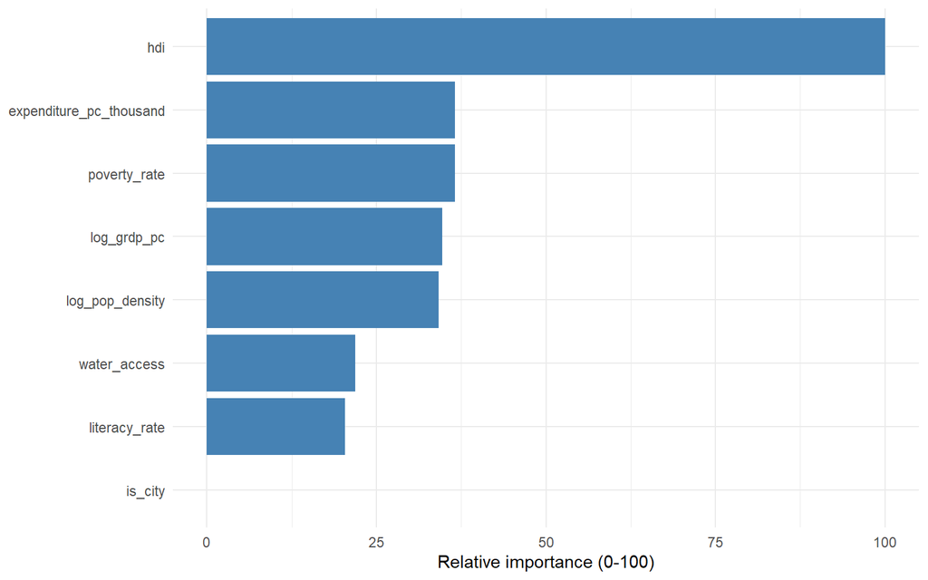

Variable importance of the best model

```r
imp <- read_csv("output/variable_importance.csv", show_col_types = FALSE)
imp %>%
  ggplot(aes(x = reorder(variable, Overall), y = Overall)) +
  geom_col(fill = "steelblue") +
  coord_flip() +
  labs(x = NULL, y = "Relative importance (0-100)") +
  theme_minimal()
```

### 4.5.3 Partial Dependence

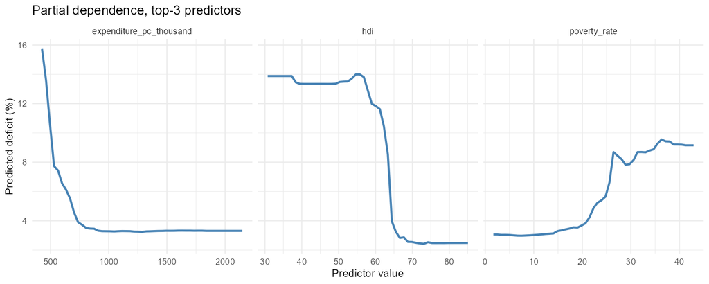

Partial dependence of the predicted deficit on the top-3 predictors

```r
include_graphics("output/partial_dependence.png")
```

The partial dependence plots reveal a strongly non-linear HDI effect: the predicted deficit is flat and low for HDI above roughly 60, then rises steeply as HDI falls below that threshold. This threshold behaviour – invisible to a linear model – explains the tree models’ advantage and suggests that districts below HDI $\approx$ 60 constitute a qualitatively distinct policy group.

### 4.5.4 Policy Simulation

```r
sim <- read_csv("output/policy_simulation.csv", show_col_types = FALSE)
show_table(sim %>%
             rename(`Mean predicted deficit (%)` = mean_deficit,
                    `Change vs baseline (pp)` = change_vs_baseline),
           "Predicted national mean deficit under counterfactual scenarios",
           digits = 2)
```

Predicted national mean deficit under counterfactual scenarios

| Scenario | Mean predicted deficit (%) | Change vs baseline (pp) |
| --- | --- | --- |
| Baseline | 3.45 | 0.00 |
| HDI +5 points | 2.80 | -0.65 |
| Poverty -25% | 3.16 | -0.29 |
| Water access +10 pp | 3.21 | -0.24 |
| Combined | 2.24 | -1.21 |

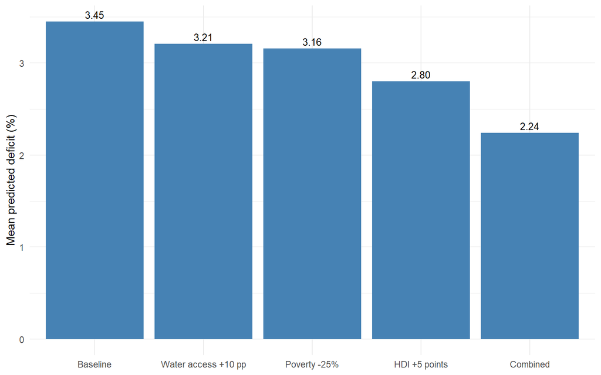

Scenario comparison of the predicted mean access deficit

```r
sim %>%
  ggplot(aes(x = reorder(Scenario, -mean_deficit), y = mean_deficit)) +
  geom_col(fill = "steelblue") +
  geom_text(aes(label = sprintf("%.2f", mean_deficit)), vjust = -0.4, size = 3.4) +
  labs(x = NULL, y = "Mean predicted deficit (%)") +
  theme_minimal()
```

Under the model, a five-point HDI improvement is associated with the largest single reduction in the predicted mean deficit (0.65 pp), and the combined scenario roughly a 1.2-pp reduction – about a third of the baseline mean. Two caveats are essential. First, these are *associative* counterfactuals from a predictive model, not causal estimates. Second, because the deficit is concentrated in a few dozen districts, national means understate what such changes would imply locally: the gains accrue almost entirely in the eastern hotspot districts.

## 4.6 Discussion

# 5 Conclusion and Recommendations

## 5.2 Policy Implications

1. **Target the identified hotspots.** The 52 Gi* hotspot districts are a concrete priority list for the remaining electrification effort.
2. **Choose technology by geography.** Sparse highland and island districts are candidates for solar mini-grids and off-grid systems rather than costly grid extension.
3. **Bundle interventions.** The tight HDI-deficit link suggests electrification programmes should be coordinated with education, health, and poverty programmes in the same districts.
4. **Monitor at district level.** Provincial averages hide within-province pockets such as Kepulauan Mentawai; district-level (or finer) monitoring is necessary.

## 5.3 Limitations

1. **Cross-sectional design.** A single year (2019) precludes dynamic or causal analysis.
2. **Access is binary and supply-side.** The household-access measure ignores reliability, hours of supply, and affordability.
3. **Omitted geography.** Terrain ruggedness, distance to the existing grid, and island isolation are not in the feature set and likely explain much of the residual variance.
4. **Centroid-based weights.** k-NN weights on centroids approximate, but do not fully capture, real connectivity in an archipelago.
5. **Predictive, not causal.** All model-based scenario results are associations; they cannot support causal claims about interventions.

## 5.4 Future Research

1. Panel analysis of the 1996-2020 DAPOER series to study convergence in access.
2. Adding terrain, grid-distance, and night-lights covariates.
3. Causal evaluation of specific programmes (e.g. pre-electrification solar-lamp schemes) with quasi-experimental designs.
4. Measuring reliability and affordability, not just connection status.

## 5.5 Concluding Remark

Indonesia’s electrification achievement is real, but its final chapter is a spatial one. The remaining unserved households are concentrated in a small, well-identified set of eastern districts where low human development, poverty, and geographic isolation reinforce one another. Data-driven spatial targeting – of the kind demonstrated here with fully public data – can help direct the last mile of the effort to exactly those places.

# 6 Acknowledgement of Sources and Academic Integrity

In line with the *Harvard Guide to Using Sources* (Harvard College Writing Program, n.d.) and the HarvardX honor code, the author confirms that this report is original work. All data are drawn from the publicly available INDO-DAPOER database (World Bank & BPS-Statistics Indonesia, 2022) and the geoBoundaries project (Runfola et al., 2020), both cited in full below with retrieval details. Every statistical method, theoretical framework, and software package used is attributed to its original authors through in-text citations and the reference list; all remaining analysis, interpretation, and writing are the author’s own. This work has not been submitted for credit in any other course.

# 7 References

Anselin, L. (1988). *Spatial Econometrics: Methods and Models*. Dordrecht: Kluwer Academic Publishers.

Anselin, L. (1995). Local indicators of spatial association – LISA. *Geographical Analysis*, 27(2), 93-115.

Badan Pusat Statistik. (2021). *Statistik Indonesia 2021*. Jakarta: BPS.

Bivand, R., Pebesma, E., & Gómez-Rubio, V. (2013). *Applied Spatial Data Analysis with R* (2nd ed.). New York: Springer.

Breiman, L. (2001). Random forests. *Machine Learning*, 45(1), 5-32.

Chen, T., & Guestrin, C. (2016). XGBoost: A scalable tree boosting system. *Proceedings of the 22nd ACM SIGKDD International Conference on Knowledge Discovery and Data Mining*, 785-794.

Friedman, J., Hastie, T., & Tibshirani, R. (2010). Regularization paths for generalized linear models via coordinate descent. *Journal of Statistical Software*, 33(1), 1-22.

Getis, A., & Ord, J. K. (1992). The analysis of spatial association by use of distance statistics. *Geographical Analysis*, 24(3), 189-206.

Harvard College Writing Program. (n.d.). *Harvard Guide to Using Sources: Avoiding Plagiarism*. Cambridge, MA: Harvard College Writing Program. https://usingsources.fas.harvard.edu

Hirschman, A. O. (1958). *The Strategy of Economic Development*. New Haven: Yale University Press.

IEA. (2020). *SDG7: Data and Projections*. Paris: International Energy Agency.

Kementerian ESDM. (2021). *Rencana Umum Ketenagalistrikan Nasional 2019-2038*. Jakarta: Kementerian Energi dan Sumber Daya Mineral.

Liaw, A., & Wiener, M. (2002). Classification and regression by randomForest. *R News*, 2(3), 18-22.

Moran, P. A. P. (1950). Notes on continuous stochastic phenomena. *Biometrika*, 37(1/2), 17-23.

Myrdal, G. (1957). *Economic Theory and Under-developed Regions*. London: Duckworth.

Ord, J. K., & Getis, A. (1995). Local spatial autocorrelation statistics: Distributional issues and an application. *Geographical Analysis*, 27(4), 286-306.

R Core Team. (2024). *R: A language and environment for statistical computing*. Vienna: R Foundation for Statistical Computing. https://www.R-project.org

Runfola, D., Anderson, A., Baier, H., Crittenden, M., Dowker, E., Fuhrig, S., et al. (2020). geoBoundaries: A global database of political administrative boundaries. *PLoS ONE*, 15(4), e0231866.

Wickham, H. (2016). *ggplot2: Elegant Graphics for Data Analysis* (2nd ed.). New York: Springer.

World Bank. (2021). *Access to electricity (% of population)* [Data set]. World Bank Open Data. https://data.worldbank.org/indicator/EG.ELC.ACCS.ZS

World Bank & BPS-Statistics Indonesia. (2022). *Indonesia Database for Policy and Economic Research (INDO-DAPOER)* [Data set]. World Bank Data Catalog. https://datacatalog.worldbank.org/search/dataset/0038570

# 8 Appendix: Reproducibility

The complete pipeline is reproducible from public sources:

1. `build_dataset.R` – parses the archived INDO-DAPOER API responses (`data/raw_dapoer/`) and the geoBoundaries ADM2 file, matches districts, and writes `data/dapoer_district_2019.csv`.
2. `analysis_electricity_access_inequality_indonesia_FINAL.R` – runs the exploratory, spatial, and machine-learning analyses and writes all figures and tables to `output/`.
3. This document renders the report from those outputs.